# Where Should Patrick Show Up?

A Data-Driven Scheduling Guide for Patrick’s Auto Shop Network

Published

May 13, 2026

## The Bottom Line

Based on 250 days of data, **Shop 4 appears to benefit most from Patrick’s presence, followed by Shops 2, 5, and 1.** Shop 3 shows the smallest observed boost and should receive lower scheduling priority — though more data would help confirm this. The data suggest Patrick can meaningfully increase total output by shifting his visits toward the highest-impact shops.

## What the Data Shows

Over 250 recorded days, Patrick’s presence is associated with higher output at every shop — but the *size* of that boost varies considerably. The chart below shows every single day on record.

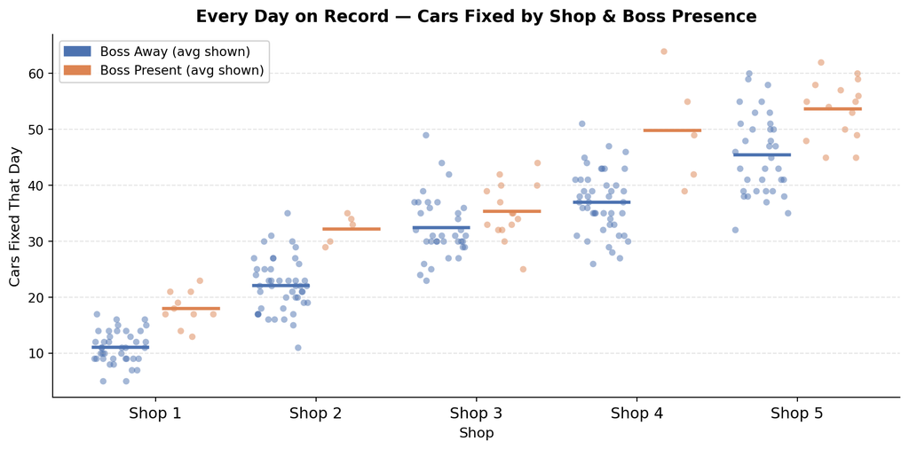

Figure 1: All 250 daily observations. Each dot = one day at one shop. Orange = Patrick present, Blue = Patrick away. Horizontal lines mark the daily average for each group.

## How Much Does Patrick’s Presence Appear to Help?

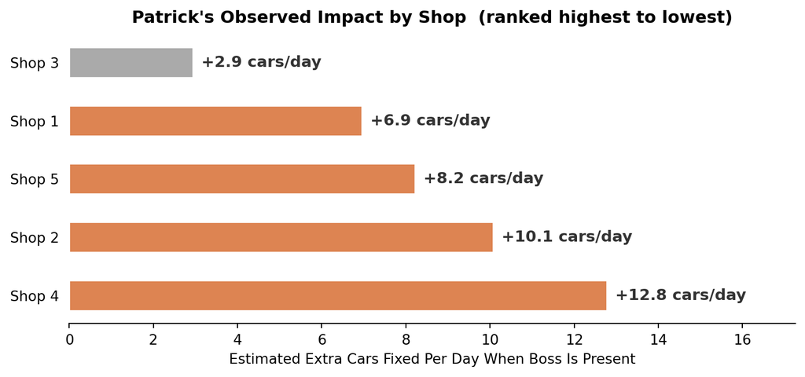

| Shop | Avg Without Patrick | Avg With Patrick | Extra Cars/Day | % Lift |
| --- | --- | --- | --- | --- |
| Shop 4 | 37.0 | 49.8 | **+12.8** | +35% |
| Shop 2 | 22.1 | 32.2 | **+10.1** | +46% |
| Shop 5 | 45.5 | 53.7 | **+8.2** | +18% |
| Shop 1 | 11.1 | 18.0 | **+6.9** | +63% |
| Shop 3 | 32.5 | 35.4 | +2.9 | +9% |

## How Confident Can Patrick Be?

Not every number above is equally trustworthy. Some shops have far fewer boss-present days in the record than others, which affects how reliable the estimates are.

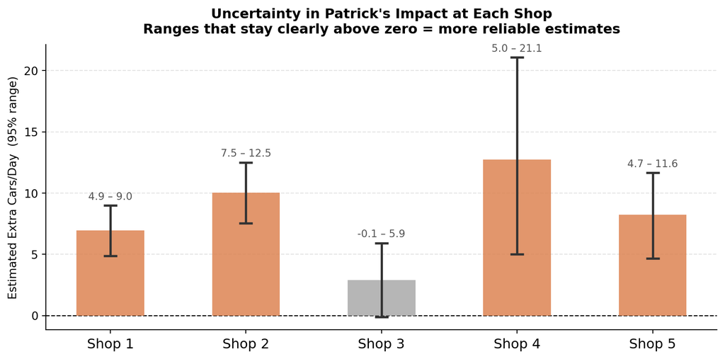

Figure 3: Bars show the estimated boost Patrick adds at each shop. Lines show the realistic range — where the true effect likely falls 19 times out of 20. Ranges that stay clearly above zero reflect more credible estimates.

**What this means in plain English:**

> **Think of it like diagnosing a car by sound.** If you hear the same knock on four out of five test drives, you act on it. The fifth test where the noise is faint doesn’t mean there’s no problem — it means you need more information before drawing a firm conclusion.

## Recommended Scheduling Strategy

Based on the data, Patrick’s visits appear to generate the most value at Shops 4 and 2, with meaningful gains at Shops 5 and 1 as well. Shop 3 shows the smallest observed impact and should receive lower scheduling priority **until more data are collected.**

**Suggested priority order: Shop 4 → Shop 2 → Shop 5 → Shop 1 → Shop 3**

### Sample Weekly Schedule

| Day | Shop | Rationale |
| --- | --- | --- |
| Monday | Shop 4 | Largest estimated boost (+12.8 cars/day) |
| Tuesday | Shop 2 | Second-highest lift (+10.1 cars/day) |
| Wednesday | Shop 5 | Solid, consistent impact (+8.2 cars/day) |
| Thursday | Shop 1 | Strong percentage gain (+63%) |
| Friday | Shop 3 / flexible | Lowest observed lift — and a great day to visit family |

Patrick loves his brother at Shop 3, and there’s nothing wrong with keeping that Friday visit. The data suggest it should be the *lowest-priority* day, not the first — but it isn’t a wasted trip either.

## What Could This Mean for Revenue?

The chart below compares two 250-day scenarios using observed averages. The only difference between them is how Patrick’s visits are distributed across shops — the total number of visit-days stays the same.

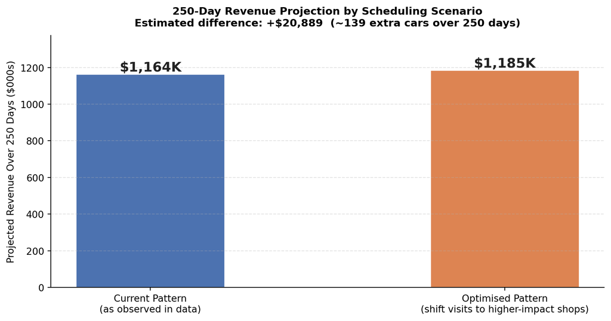

Figure 4: Projected total revenue over a 250-day period under two scheduling approaches. Assumes $150 per car — adjust if your average ticket price differs.

> **Assumption check:** The dollar amounts above use $150/car as a placeholder. The gap between the two bars — representing the opportunity from smarter scheduling — is what matters most here. That gap holds regardless of the exact price per car.

## Risks and Assumptions

No data analysis is perfect. Patrick should keep these points in mind before acting:

1. **Small samples at some shops.** Shops 2 and 4 have only 5 boss-present days on record. The averages look strong, but a handful of unusual days could be influencing them. More data would increase confidence.
2. **Association, not proven cause.** The data show a *link* between Patrick’s visits and higher output — but they don’t rule out other explanations. Perhaps he tends to visit certain shops on naturally better days. More systematic tracking would help clarify this.
3. **Things change.** Staff turnover, new competition, or a great new hire can shift these numbers over time. This analysis should be revisited every 6–12 months.
4. **Shop 3 is not ruled out.** With only 15 boss-present observations, we can’t confidently conclude Patrick’s presence doesn’t help there. A deliberate 30-day trial of consistent visits to Shop 3 would give a much clearer picture.
5. **One visit per day assumed.** If Patrick can do half-days or split time across locations, the optimal strategy may look different.

## Action Plan

**TipThree Steps Patrick Can Take This Week**

1. **Shift scheduling priority** toward Shops 4, 2, 5, and 1 — in that order. Treat Shop 3 as a flexible day or family visit until more data are available.
2. **Keep tracking consistently.** Log boss-present vs. absent days going forward. Another 250 days of clean data will sharpen these recommendations considerably.
3. **Consider a Shop 3 trial.** If Patrick wants to settle the question on Shop 3, commit to 30 consecutive visits and compare output. The data will tell the story.

*Analysis based on 250 days of productivity data across 5 shops. Revenue projections use $150/car and reflect the same 250-day window as the dataset. Uncertainty ranges are 95% bootstrap confidence intervals on the estimated difference in daily output (boss present vs. absent).*